# Comandos Básicos de R

Jose Storopoli

Este arquivo é um documento [R Markdown](http://rmarkdown.rstudio.com) Quando você executa um código nesse documentom os resultados aparecem abaixo do código.

Para executar um código clique no botão *Run* (*play* em cor verde) ou coloque o seu cursos dentro do código e aperte *Ctrl+Shift+Enter*.

```r
print("Você executou um código")
```

```
[1] "Você executou um código"
```

Você pode adicionar um novo código clicando no botão *Insert Chunk* na *toolbar* ou apertando *Crtl+Alt+I*.

Quando você salva esse notebook, um arquivo HTML contendo o código e os resultados será salvo junto com ele (clique no botão *Preview* ou aperte *Crtl+Shift+K* para visualizar o arquivo HTML).

Essa visualização mostra uma copia renderizada em HTML do editor do R. Ao contrário do botão *Knit*, *Preview* não executra nenhum código de R. Ele apenas exibe o output do código quando foi executado a última vez. Além disso, o botão *Knit* permite com que você renderize o documento como HTML, PDF ou Word.

## Lendo Arquivos

### CSV

Para ler um arquivo CSV (`.csv`) no R execute a função `read.csv()` para arquivos CSV formato americano (vírgula como separador e decimais como ponto) ou a função `read.csv2()` para arquivos CSV formato europeu/brasileiro (ponto-e-vírgula como separador e decimais como vírgula). Não esqueça de designar a leitura para uma variável com o designador `<-`.

```r
df <- read.csv2("datasets/mtcars.csv", row.names = 1)
head(df)
```

|  | mpg | cyl | disp | hp | drat | wt | qsec | vs | am | gear | carb |
| --- | --- | --- | --- | --- | --- | --- | --- | --- | --- | --- | --- |
| Mazda RX4 | 21 | 6 | 160 | 110 | 3.9 | 2.6 | 16 | 0 | 1 | 4 | 4 |
| Mazda RX4 Wag | 21 | 6 | 160 | 110 | 3.9 | 2.9 | 17 | 0 | 1 | 4 | 4 |
| Datsun 710 | 23 | 4 | 108 | 93 | 3.9 | 2.3 | 19 | 1 | 1 | 4 | 1 |
| Hornet 4 Drive | 21 | 6 | 258 | 110 | 3.1 | 3.2 | 19 | 1 | 0 | 3 | 1 |
| Hornet Sportabout | 19 | 8 | 360 | 175 | 3.1 | 3.4 | 17 | 0 | 0 | 3 | 2 |
| Valiant | 18 | 6 | 225 | 105 | 2.8 | 3.5 | 20 | 1 | 0 | 3 | 1 |

### Excel

Para ler um arquivo Excel (`.xls` ou `.xlsx`) no R é necessário importar um pacote chamado `readxl` que contem a função `read_excel`. Para importar um pacote no R executamos o comando `library()` com um argumento único sendo o nome do pacote. Caso não tenha o pacote instalado, deve instalar ele com o comando `install.packages()`. Não esqueça de colocar o nome do pacote entre aspas `"nome_do_pacote"` dentro do parênteses da função.

```r
# install.packages("readxl")
library(readxl)
df <- read_excel("datasets/mtcars.xlsx")
```

```
* `` -> ...1
```

```r
head(df)
```

| ...1 | mpg | cyl | disp | hp | drat | wt | qsec | vs | am | gear | carb |
| --- | --- | --- | --- | --- | --- | --- | --- | --- | --- | --- | --- |
| Mazda RX4 | 21 | 6 | 160 | 110 | 3.9 | 2.6 | 16 | 0 | 1 | 4 | 4 |
| Mazda RX4 Wag | 21 | 6 | 160 | 110 | 3.9 | 2.9 | 17 | 0 | 1 | 4 | 4 |
| Datsun 710 | 23 | 4 | 108 | 93 | 3.9 | 2.3 | 19 | 1 | 1 | 4 | 1 |
| Hornet 4 Drive | 21 | 6 | 258 | 110 | 3.1 | 3.2 | 19 | 1 | 0 | 3 | 1 |
| Hornet Sportabout | 19 | 8 | 360 | 175 | 3.1 | 3.4 | 17 | 0 | 0 | 3 | 2 |
| Valiant | 18 | 6 | 225 | 105 | 2.8 | 3.5 | 20 | 1 | 0 | 3 | 1 |

## Gráficos

Geralmente no R você pode *plotar* diversos objetos (variáveis do ambiente) com o comando `plot()`. Quando você *plota* um dataset (conjunto de dados lido de um aquivo), o R retorna um gráfico chamado *Pair Plot*:

- Na diagonal: nome da variável (coluna do dataset)
- Fora da diagonal: um gráfico de dispersão entre a variável no eixo horizontal e a variável no eixo vertical

Exemplo: Veja a relação entre `disp` (cilindrada) e `hp` (cavalos de potência). Ela é uma relação positiva. Quanto maior `disp` maior `hp`.

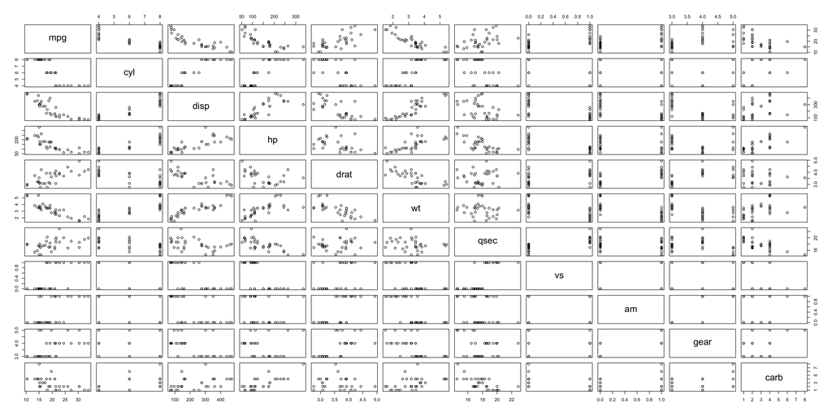

```r
plot(mtcars)
```